# air_pollution_temperature slides

## Does the air pollution of a country have a direct influence on the annual temperature change?

[figure not shown]

DALL-E - https://labs.openai.com/s/RSwBxy06nQrqfD2dtYaEW9sS

### 1. Business Understanding:

We all know that air pollution is a factor in climate change. What we also know is that this is a global problem. But could it also be that the emissions of a country could already have a direct influence on the temperature change of that country?

Datasets:

- Community Emissions Data System (CEDS)
- FAOSTAT Temperature Change

Data Sources

CEDS-Data: https://ourworldindata.org/explorers/air-pollution

FAOSTAT-Temperature-Data: https://www.fao.org/faostat/en/#data/ET

### 2. Data Understanding

#### 2.1 Data Understanding - Emmisions data (CEDS)

```python
df_emmisions.sample(3)
```

|  | Nitrogen oxide (NOx) | Sulphur dioxide (SO₂) | Carbon monoxide (CO) | Organic carbon (OC) | NMVOCs | Black carbon (BC) | Ammonia (NH₃) | Entity | Year |
| --- | --- | --- | --- | --- | --- | --- | --- | --- | --- |
| 29388 | 870.826600 | 1859.591349 | 325242.182382 | 13303.393495 | 30223.179887 | 3589.252406 | 18808.965241 | Nepal | 1868 |
| 9967 | 48.590051 | 2379.672665 | 44402.667659 | 1689.647682 | 5746.794527 | 151.346485 | 8186.210853 | Croatia | 1852 |
| 38158 | 32.775166 | 63.421711 | 13128.780424 | 552.509971 | 2334.357006 | 49.151477 | 2371.059206 | Slovenia | 1823 |

```python
df_emmisions.describe()
```

|  | Nitrogen oxide (NOx) | Sulphur dioxide (SO₂) | Carbon monoxide (CO) | Organic carbon (OC) | NMVOCs | Black carbon (BC) | Ammonia (NH₃) | Year |
| --- | --- | --- | --- | --- | --- | --- | --- | --- |
| count | 4.753500e+04 | 4.753500e+04 | 4.753500e+04 | 4.753500e+04 | 4.753500e+04 | 4.753500e+04 | 4.753500e+04 | 47535.000000 |
| mean | 5.260436e+05 | 7.992584e+05 | 5.173733e+06 | 1.302651e+05 | 8.868047e+05 | 4.678637e+04 | 3.417240e+05 | 1909.436731 |
| std | 4.332972e+06 | 5.743331e+06 | 3.059404e+07 | 6.744725e+05 | 5.927514e+06 | 2.771701e+05 | 2.250404e+06 | 66.777467 |
| min | 0.000000e+00 | 0.000000e+00 | 0.000000e+00 | 0.000000e+00 | 0.000000e+00 | 0.000000e+00 | 0.000000e+00 | 1750.000000 |
| 25% | 1.548467e+02 | 6.235476e+01 | 1.469565e+04 | 6.073753e+02 | 2.245105e+03 | 1.514704e+02 | 1.399557e+03 | 1853.000000 |
| 50% | 1.689596e+03 | 8.450006e+02 | 1.163538e+05 | 4.364754e+03 | 1.728262e+04 | 1.065555e+03 | 9.817929e+03 | 1912.000000 |
| 75% | 2.899340e+04 | 3.199098e+04 | 6.540220e+05 | 2.160645e+04 | 1.139918e+05 | 6.333218e+03 | 5.276752e+04 | 1968.000000 |
| max | 1.095663e+08 | 1.335263e+08 | 6.616236e+08 | 1.401013e+07 | 1.468331e+08 | 6.314146e+06 | 6.142059e+07 | 2019.000000 |

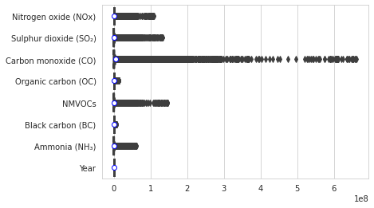

```python
sn.boxplot(data=df_emmisions, orient="h", palette="Set1", linewidth=2.5, notch=True,  showmeans=True, meanprops={"marker":"o","markerfacecolor":"white", "markeredgecolor":"blue"})
```

Lets use the zscore to see the scattering of the column values in the dataframe

```python
from scipy.stats import zscore
```

```python
def abs_zscore(x):
    return np.abs(zscore(x))

df_numeric = df_emmisions.select_dtypes(include=np.number)

df_zscore = df_numeric.apply(abs_zscore)
```

```python
threshold = 5
outliers = df_emmisions[(df_zscore>threshold).any(axis='columns')]
none_outliers = df_emmisions[~(df_zscore>threshold).any(axis='columns')]
```

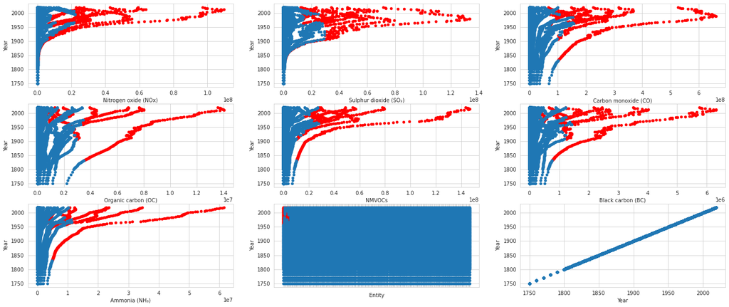

```python
def plot_outliers(outliers, none_outliers, number_of_cols, number_of_rows, figsize=(24, 10)):
    fig, axes = plt.subplots(number_of_cols, number_of_rows, figsize=figsize)
    axe = axes.ravel()

    # assign the plot to each subplot in axe
    for i, c in enumerate(outliers.columns):
        outliers[[c, 'Year']].plot(kind='scatter', x=c, y='Year', ax=axe[i], color='red')
        none_outliers[[c, 'Year']].plot(kind='scatter', x=c, y='Year', ax=axe[i])
        if c == 'Entity':
            axe[i].set(xticklabels=[])

plot_outliers(outliers, none_outliers, 3, 3, (24, 10))
```

```python
# get outlier values of Entity
outliers['Entity'].unique()
```

```
array(['Asia', 'China', 'Europe', 'High-income countries',
       'Lower-middle-income countries', 'North America', 'United States',
       'Upper-middle-income countries', 'World'], dtype=object)
```

As we can see, the dataset also contains calculations for complete continents and grouped countries.

We only want to research on a country level. Thats why these values can be removed.

```python
none_countries = ['Asia', 'Africa', 'Europe', 'High-income countries',
       'Lower-middle-income countries', 'North America', 'South America',
       'Upper-middle-income countries', 'World']

df_emmisions = df_emmisions[~df_emmisions['Entity'].isin(none_countries)]
```

```python
plotly.offline.init_notebook_mode(connected=True)
px.choropleth(data_frame=df_emmisions,
 locationmode='country names',locations='Entity', color='Carbon monoxide (CO)',animation_frame='Year',
  title='Carbon emission by country and year',color_continuous_scale=plotly.express.colors.sequential.Plasma,range_color=(100, 0))
```

[interactive chart not shown]

#### 2.2 Data Understanding - Temperature data (FAOSTAT)

```python
df_temperature.sample(3)
```

|  | Domain Code | Domain | Area Code (M49) | Area | Element Code | Element | Months Code | Months | Year Code | Year | Unit | Value | Flag | Flag Description |
| --- | --- | --- | --- | --- | --- | --- | --- | --- | --- | --- | --- | --- | --- | --- |
| 22025 | ET | Temperature change | 690 | Seychelles | 7271 | Temperature change | 7020 | Meteorological year | 1966 | 1966 | °C | 0.070 | E | Estimated value |
| 4271 | ET | Temperature change | 136 | Cayman Islands | 7271 | Temperature change | 7020 | Meteorological year | 1966 | 1966 | °C | -0.238 | E | Estimated value |
| 8703 | ET | Temperature change | 234 | Faroe Islands | 6078 | Standard Deviation | 7020 | Meteorological year | 2011 | 2011 | °C | 0.469 | E | Estimated value |

"The FAOSTAT Temperature Change domain disseminates statistics of mean surface temperature change by country, with annual updates. Corresponding to the period 1951–1980"

https://www.fao.org/faostat/en/#data/ET/metadata

```python
def temperature_df_preperation(df):
    df = df.drop(df[df_temperature.Element == "Standard Deviation"].index)
    df = df.rename(columns={'Value': 'Temperature Change'})
    return df

df_temperature = temperature_df_preperation(df_temperature)
df_temperature.describe()
```

|  | Area Code (M49) | Element Code | Months Code | Year Code | Year | Temperature Change |
| --- | --- | --- | --- | --- | --- | --- |
| count | 13764.000000 | 13764.0 | 13764.0 | 13764.000000 | 13764.000000 | 13248.000000 |
| mean | 434.256103 | 7271.0 | 7020.0 | 1991.821854 | 1991.821854 | 0.505521 |
| std | 254.729597 | 0.0 | 0.0 | 17.615063 | 17.615063 | 0.648806 |
| min | 4.000000 | 7271.0 | 7020.0 | 1961.000000 | 1961.000000 | -3.251000 |
| 25% | 212.000000 | 7271.0 | 7020.0 | 1977.000000 | 1977.000000 | 0.047750 |
| 50% | 430.000000 | 7271.0 | 7020.0 | 1993.000000 | 1993.000000 | 0.436000 |
| 75% | 654.000000 | 7271.0 | 7020.0 | 2007.000000 | 2007.000000 | 0.901000 |
| max | 894.000000 | 7271.0 | 7020.0 | 2021.000000 | 2021.000000 | 5.327000 |

```python
px.choropleth(data_frame=df_temperature, locationmode='country names', locations='Area',
 color='Temperature Change', animation_frame='Year', title='Annual temperature change per country',
 color_continuous_scale=plotly.express.colors.sequential.Plasma, range_color=(100, 0))
```

[interactive chart not shown]

### 3. Data Preparation

We need to clean columns and rows that are not intresting in both datasets.

Additionally we want to merge both dataframes for further analysis.

We want to merge the two dataframes by Year->Year and Entity->Area unfortunaly it looks like not all Entity labels are the same as the Area labels.

```python
# compare Area and Entity in both data sets
import difflib

df_emmisions_countries = df_emmisions.Entity.unique()
df_temperature_countries = df_temperature.Area.unique()

diff_countries = set(df_temperature_countries).difference(set(df_emmisions_countries))

for country in diff_countries:
    print(country, difflib.get_close_matches(country, df_emmisions_countries))
```

```
Timor-Leste ['Timor']
Türkiye ['Turkey']
Pitcairn []
Yugoslav SFR []
Norfolk Island ['Cook Islands', 'Faeroe Islands', 'Solomon Islands']
Viet Nam ['Vietnam']
Mayotte []
Cocos (Keeling) Islands ['Cook Islands']
China, Macao SAR []
Sudan (former) []
USSR []
Svalbard and Jan Mayen Islands []
French Southern Territories []
Serbia and Montenegro ['Montenegro']
United States of America ['United States', 'United States Virgin Islands']
Holy See []
Pacific Islands Trust Territory []
Midway Island ['Cayman Islands', 'Marshall Islands']
Bolivia (Plurinational State of) []
Democratic People's Republic of Korea ['Democratic Republic of Congo']
French Guyana ['French Guiana', 'French Polynesia', 'Guyana']
Nauru []
Isle of Man []
Belgium-Luxembourg ['Luxembourg']
Faroe Islands ['Faeroe Islands', 'Cook Islands', 'Marshall Islands']
San Marino []
Czechoslovakia ['Czechia', 'Slovakia']
Ethiopia PDR ['Ethiopia']
Tuvalu []
China, Hong Kong SAR ['Hong Kong']
Réunion ['Reunion']
Côte d'Ivoire ["Cote d'Ivoire"]
South Georgia and the South Sandwich Islands []
United Kingdom of Great Britain and Northern Ireland []
Iran (Islamic Republic of) []
Saint Helena, Ascension and Tristan da Cunha []
Antarctica []
United Republic of Tanzania []
China, Taiwan Province of []
Monaco ['Macao', 'Morocco']
Russian Federation []
Palestine []
Anguilla ['Angola']
Wallis and Futuna Islands ['Wallis and Futuna', 'Falkland Islands', 'Turks and Caicos Islands']
Syrian Arab Republic ['Dominican Republic']
Falkland Islands (Malvinas) ['Falkland Islands']
Channel Islands ['Cayman Islands', 'Marshall Islands', 'Faeroe Islands']
Brunei Darussalam []
Republic of Moldova []
Lao People's Democratic Republic ['Democratic Republic of Congo']
Cabo Verde ['Cape Verde']
China, mainland ['Cayman Islands', 'Thailand']
Wake Island ['Faeroe Islands', 'Cook Islands', 'Falkland Islands']
Democratic Republic of the Congo ['Democratic Republic of Congo']
Christmas Island ['Cayman Islands']
Venezuela (Bolivarian Republic of) []
Micronesia (Federated States of) []
Andorra ['Angola']
Netherlands Antilles (former) []
Republic of Korea []
```

```python
# read in edited temperature dataframe
df_temperature =  pd.read_csv(base_path+"/temperature_data_2019_country_corrected.csv", sep=',')
df_temperature = temperature_df_preperation(df_temperature)
df_temperature = df_temperature.dropna()

# merge data sets
df_merged = pd.merge(df_emmisions, df_temperature,  how='inner', left_on=['Entity','Year'], right_on = ['Area','Year'])

# remove unnecessary columns
df_merged = df_merged[['Nitrogen oxide (NOx)', 'Sulphur dioxide (SO₂)', 'Carbon monoxide (CO)','Organic carbon (OC)', 'NMVOCs', 'Black carbon (BC)', 'Ammonia (NH₃)', 'Year', 'Temperature Change', 'Entity']]
```

Let's create a simple linear correlation heatmap. Between the pollution values and the temperature change value. The data is currently not grouped by country.

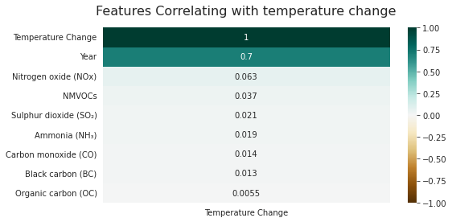

```python
plt.figure(figsize=(8, 4))
heatmap = sn.heatmap(df_merged.corr()[['Temperature Change']].sort_values(by='Temperature Change', ascending=False), vmin=-1, vmax=1, annot=True, cmap='BrBG')
heatmap.set_title('Features Correlating with temperature change', fontdict={'fontsize':16}, pad=16);
```

Let's try this correlation analysis with data that comes only from the country the emission were produced in.

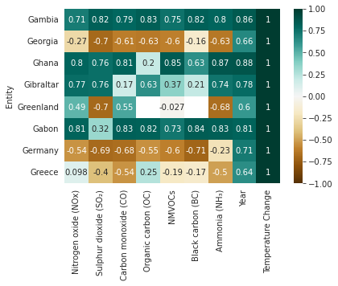

```python
corrs_per_country = df_merged.groupby(['Entity']).corrwith(df_merged['Temperature Change'])
heatmap = sn.heatmap(corrs_per_country.iloc[65:73].sort_values(by='Temperature Change', ascending=False), vmin=-1, vmax=1, annot=True, cmap='BrBG')
```

```python
# prepare a model (58 Years of data per country) and leave out 2019 for later evaluation
df_regression_germany = df_prepared[(df_prepared['Entity']=='Germany') & (df_prepared['Year']<2019)]
df_regression_all = df_prepared[(df_prepared['Year']<2019)]

df_evaluation_germany = df_prepared[(df_prepared['Entity']=='Germany') & (df_prepared['Year']>=2019)]
df_evaluation_all = df_prepared[(df_prepared['Year']>=2019)]
```

```python
from sklearn.model_selection import train_test_split
from sklearn.preprocessing import MinMaxScaler
from sklearn.metrics import mean_squared_error

scaler = MinMaxScaler()

df_regression_x = df_regression_germany[['Nitrogen oxide (NOx)', 'Sulphur dioxide (SO₂)', 'Carbon monoxide (CO)','Organic carbon (OC)', 'NMVOCs', 'Black carbon (BC)', 'Ammonia (NH₃)', 'Year']]
df_regression_y = df_regression_germany[['Temperature Change']]
X_train, X_test, y_train, y_test = train_test_split(df_regression_x, df_regression_y, test_size=0.2, random_state=42, shuffle=True)

# later used for evaluation
X_test_original = X_test.copy()

# min max scale data between 0 and 1
X_train = scaler.fit_transform(X_train)
X_test = scaler.transform(X_test)
y_train = scaler.fit_transform(y_train)
y_test = scaler.transform(y_test)
```

### 4. Modeling

[figure not shown]

Sample Decission Tree

```python
# hyperparameters were tuned with RandomizedSearchCV
germany_regressor = RandomForestRegressor(n_estimators=4, min_samples_split=2, min_samples_leaf=4, max_features="sqrt", max_depth=10, bootstrap=False)

germany_regressor.fit(X_train, y_train.ravel())
```

```
RandomForestRegressor(bootstrap=False, max_depth=10, max_features='sqrt',
                      min_samples_leaf=4, n_estimators=4)
```

### 5. Evaluation

```python
# predict values
y_pred = germany_regressor.predict(X_test)
```

```python
print('Mean Squared Error Germany for testing data:', mse_germany)
```

```
Mean Squared Error Germany for testing data: 0.33113319300108873
```

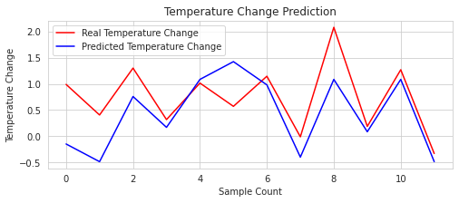

```python
# plot results
plt.figure(figsize=(8, 3))
plt.plot(y_test_rescaled, color = 'red', label = 'Real Temperature Change')
plt.plot(y_pred, color = 'blue', label = 'Predicted Temperature Change')
plt.title('Temperature Change Prediction')
plt.xlabel('Sample Count')
plt.ylabel('Temperature Change')
plt.legend()
plt.show()
```

```python
def model_by_country(df):
    df_regression_x = df[['Nitrogen oxide (NOx)', 'Sulphur dioxide (SO₂)', 'Carbon monoxide (CO)','Organic carbon (OC)', 'NMVOCs', 'Black carbon (BC)', 'Ammonia (NH₃)', 'Year']]
    df_regression_y = df[['Temperature Change']]
    X_train, X_test, y_train, y_test = train_test_split(df_regression_x, df_regression_y, test_size=0.2, random_state=42, shuffle=True)

    regressor = RandomForestRegressor(n_estimators=4, min_samples_split=2, min_samples_leaf=4, max_features="sqrt", max_depth=10, bootstrap=False)
    return regressor.fit(X_train, y_train.values.ravel())


df_model_by_country = df_regression_all.groupby(['Entity']).apply(model_by_country)
df_model_by_country = df_model_by_country.reset_index()
df_model_by_country = df_model_by_country.rename(columns={0: 'Temperature Change Model'})
```

```python
# df_results_2019 avg for Mean Squared Error
print("MSE across all countries for 2019:",df_results_2019['Mean Squared Error'].mean())
```

```
MSE across all countries for 2019: 0.13030039903977578
```

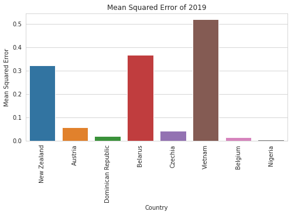

```python
# plot results of 2019
plt.figure(figsize=(8, 4))
sn.set_style("whitegrid")
sn.barplot(x="Entity", y="Mean Squared Error", data=df_results_2019.sample(8))
plt.xticks(rotation=90)
plt.title('Mean Squared Error of 2019')
plt.xlabel('Country')
plt.ylabel('Mean Squared Error')
plt.show()
```

### 6. Deployment

Now we would like to make our country based prediction models available for scientist. So that they can use measured emission values of their country to predict the temperature change for a year.

Therefore we will use flask a simple python web framework to make this possible.

https://flask.palletsprojects.com/en/2.2.x/

```python
df_model_by_country.to_pickle("./web_app/df_models_per_country.pkl")
df_prepared.to_pickle("./web_app/df_emmissions_temperatures.pkl")
```